# Football Analysis and Modelling

Ian

2023-01-13

```r
library(httr)
#install.packages('devtools')
#install.packages("worldfootballR")
library(worldfootballR)
library(tidyverse)
data1 <- worldfootballR::fb_match_results(country = "ENG", gender = "M", season_end_year = c(2019:2022))

## Simple exploration
head(data1)
```

```
##   Competition_Name Gender Country Season_End_Year Round Wk Day       Date  Time
## 1   Premier League      M     ENG            2019    NA  1 Fri 2018-08-10 20:00
## 2   Premier League      M     ENG            2019    NA  1 Sat 2018-08-11 12:30
## 3   Premier League      M     ENG            2019    NA  1 Sat 2018-08-11 15:00
## 4   Premier League      M     ENG            2019    NA  1 Sat 2018-08-11 15:00
## 5   Premier League      M     ENG            2019    NA  1 Sat 2018-08-11 15:00
## 6   Premier League      M     ENG            2019    NA  1 Sat 2018-08-11 15:00
##             Home HomeGoals Home_xG           Away AwayGoals Away_xG Attendance
## 1 Manchester Utd         2     1.5 Leicester City         1     1.8      74439
## 2  Newcastle Utd         1     1.0      Tottenham         2     2.0      51749
## 3         Fulham         0     0.7 Crystal Palace         2     1.0      24821
## 4    Bournemouth         2     2.2   Cardiff City         0     1.4      10353
## 5        Watford         2     1.2       Brighton         0     0.3      20051
## 6   Huddersfield         0     0.3        Chelsea         3     1.9      24121
##                      Venue         Referee Notes
## 1             Old Trafford  Andre Marriner    NA
## 2          St. James' Park Martin Atkinson    NA
## 3           Craven Cottage       Mike Dean    NA
## 4         Vitality Stadium    Kevin Friend    NA
## 5    Vicarage Road Stadium   Jonathan Moss    NA
## 6 The John Smith's Stadium  Chris Kavanagh    NA
##                                                                                                 MatchURL
## 1   https://fbref.com/en/matches/3ae83896/Manchester-United-Leicester-City-August-10-2018-Premier-League
## 2 https://fbref.com/en/matches/dce15e01/Newcastle-United-Tottenham-Hotspur-August-11-2018-Premier-League
## 3              https://fbref.com/en/matches/30875601/Fulham-Crystal-Palace-August-11-2018-Premier-League
## 4           https://fbref.com/en/matches/352f5574/Bournemouth-Cardiff-City-August-11-2018-Premier-League
## 5   https://fbref.com/en/matches/b3a7c703/Watford-Brighton-and-Hove-Albion-August-11-2018-Premier-League
## 6          https://fbref.com/en/matches/d82a37a7/Huddersfield-Town-Chelsea-August-11-2018-Premier-League
```

```r
colnames(data1)
```

```
##  [1] "Competition_Name" "Gender"           "Country"          "Season_End_Year"
##  [5] "Round"            "Wk"               "Day"              "Date"
##  [9] "Time"             "Home"             "HomeGoals"        "Home_xG"
## [13] "Away"             "AwayGoals"        "Away_xG"          "Attendance"
## [17] "Venue"            "Referee"          "Notes"            "MatchURL"
```

```r
## Check dates
range(data1$Date) ## Games from 2018 to 2021
```

```
## [1] "2018-08-10" "2022-05-22"
```

```r
## Subset columns of interest
#data2 <- data1 %>% select(Season_End_Year, Date, starts_with("Home"), starts_with("Away"), Referee)

## Referees over the years
#data2 %>% group_by(Referee, Season_End_Year) %>% summarise(count = n())
```

```r
## Number of games each season
data1 %>% group_by(Season_End_Year) %>% count()
```

```
## # A tibble: 4 × 2
## # Groups:   Season_End_Year [4]
##   Season_End_Year     n
##             <int> <int>
## 1            2019   380
## 2            2020   380
## 3            2021   380
## 4            2022   380
```

```r
## Get the unique teams
data1 %>% dplyr::select(Home) %>% unique()
```

```
##                 Home
## 1     Manchester Utd
## 2      Newcastle Utd
## 3             Fulham
## 4        Bournemouth
## 5            Watford
## 6       Huddersfield
## 7             Wolves
## 8        Southampton
## 9          Liverpool
## 10           Arsenal
## 11          Brighton
## 16    Leicester City
## 17           Burnley
## 18    Crystal Palace
## 20         Tottenham
## 22      Cardiff City
## 23           Everton
## 25          West Ham
## 28   Manchester City
## 29           Chelsea
## 400     Norwich City
## 402    Sheffield Utd
## 404      Aston Villa
## 765        West Brom
## 791     Leeds United
## 1141       Brentford
```

```r
# - this code can be written in a more concise way using distinct()
data1 %>% distinct(Home)
```

```
##               Home
## 1   Manchester Utd
## 2    Newcastle Utd
## 3           Fulham
## 4      Bournemouth
## 5          Watford
## 6     Huddersfield
## 7           Wolves
## 8      Southampton
## 9        Liverpool
## 10         Arsenal
## 11        Brighton
## 12  Leicester City
## 13         Burnley
## 14  Crystal Palace
## 15       Tottenham
## 16    Cardiff City
## 17         Everton
## 18        West Ham
## 19 Manchester City
## 20         Chelsea
## 21    Norwich City
## 22   Sheffield Utd
## 23     Aston Villa
## 24       West Brom
## 25    Leeds United
## 26       Brentford
```

```r
## Colnames
colnames(data1) # - interesting variables are Home xG and Away xG
```

```
##  [1] "Competition_Name" "Gender"           "Country"          "Season_End_Year"
##  [5] "Round"            "Wk"               "Day"              "Date"
##  [9] "Time"             "Home"             "HomeGoals"        "Home_xG"
## [13] "Away"             "AwayGoals"        "Away_xG"          "Attendance"
## [17] "Venue"            "Referee"          "Notes"            "MatchURL"
## [21] "Week"             "Total_goals"
```

```r
## Compare XG to actual goals?
data1 %>% dplyr::select(Home, Away, HomeGoals, AwayGoals, Home_xG, Away_xG, Season_End_Year) %>% head()
```

```
##             Home           Away HomeGoals AwayGoals Home_xG Away_xG
## 1 Manchester Utd Leicester City         2         1     1.5     1.8
## 2  Newcastle Utd      Tottenham         1         2     1.0     2.0
## 3         Fulham Crystal Palace         0         2     0.7     1.0
## 4    Bournemouth   Cardiff City         2         0     2.2     1.4
## 5        Watford       Brighton         2         0     1.2     0.3
## 6   Huddersfield        Chelsea         0         3     0.3     1.9
##   Season_End_Year
## 1            2019
## 2            2019
## 3            2019
## 4            2019
## 5            2019
## 6            2019
```

```r
## Upsets? Games where sign of (homexg - awayxg) is different from (home - away)
data_upsets <- data1 %>%
  dplyr::select(Home, Away, HomeGoals, AwayGoals, Home_xG, Away_xG, Season_End_Year) %>%
  mutate(`homexg-awayxg` = Home_xG -Away_xG,
                 `home-away` = HomeGoals -AwayGoals) %>%
  mutate(upset = round(`home-away`/ (`homexg-awayxg` + 0.01))) %>%
  mutate(upset = replace_na(upset, 0)) %>%
  rename(`actualtopredicted` = upset)

#- check
data_upsets %>% dplyr::select(actualtopredicted) %>% head()
```

```
##   actualtopredicted
## 1                -3
## 2                 1
## 3                 7
## 4                 2
## 5                 2
## 6                 2
```

Taking the differences in both expected and actual goals, by taking home scored - away scored, shows whether the home team won in terms of expected goals and actual goals. Positive expected goal diff means the home team is expected to win, and positive actual goal diff means the team did win.

Hence, I see an upset as when the expected goal diff and the actual goal diff have opposite signs. In particular, if the not only are different signs but that the actual goal diff was much larger, this could mean a bigger upset, and hence I made the `upset` metric in terms of the ratio.

Let’s check out some data for my favourite team, Liverpool FC

```r
## Upsets for Liverpool?
data_upsets %>% filter(Home == 'Liverpool' | Away == 'Liverpool') %>% select(Home, Away, `homexg-awayxg`, `home-away`, actualtopredicted) %>% arrange(Home, Away) %>% head()
```

```
##          Home      Away homexg-awayxg home-away actualtopredicted
## 1     Arsenal Liverpool           0.1         0                 0
## 2     Arsenal Liverpool          -1.3         1                -1
## 3     Arsenal Liverpool          -2.3        -3                 1
## 4     Arsenal Liverpool          -0.3        -2                 7
## 5 Aston Villa Liverpool          -2.0        -1                 1
## 6 Aston Villa Liverpool           0.9         5                 5
```

```r
## Performed better than expected VS performed worse than expected
liv_upsets <- data_upsets %>%
  filter(Home == 'Liverpool' | Away == 'Liverpool') %>% select(HomeGoals, AwayGoals, Home, Away, `homexg-awayxg`, `home-away`, actualtopredicted,Season_End_Year) %>%
  mutate(Opposition = ifelse(Home == "Liverpool", Away, Home)) %>%
  select(Opposition, actualtopredicted) %>%
  group_by(Opposition) %>%
  summarise(avg_actualtopred = mean(actualtopredicted))

## Regress?
# - first -- change the contrasts such that we get all opposition effects, and the intercept now becomes the average outcome instead of with respect to some base category/ reference category
liv_upsets$Opposition <-as.factor(liv_upsets$Opposition)
## regress the upset ratio to each of the oppositions
liv_xg_model <- lm(avg_actualtopred ~ Opposition,
   data = liv_upsets)

## Check coefficients to see performance over oppositions
liv_xg_model$coefficients
```

```
##  (Intercept)  Opposition2  Opposition3  Opposition4  Opposition5  Opposition6
##     1.375000    33.625000     0.625000    -0.875000     2.375000     3.750000
##  Opposition7  Opposition8  Opposition9 Opposition10 Opposition11 Opposition12
##     0.125000    -1.000000    -0.500000     1.375000     0.125000    -4.875000
## Opposition13 Opposition14 Opposition16 Opposition17 Opposition18 Opposition19
##    -0.875000   -12.125000    -2.625000     0.125000    -1.000000     3.875000
## Opposition20 Opposition21 Opposition22 Opposition23 Opposition24 Opposition25
##    -0.125000    -0.250000   -14.500000     1.291667    -0.875000    -1.125000
## Opposition26
##    -0.250000
```

```r
levels(liv_upsets$Opposition)[1] ## Hence the base category is Arsenal
```

```
## [1] "1"
```

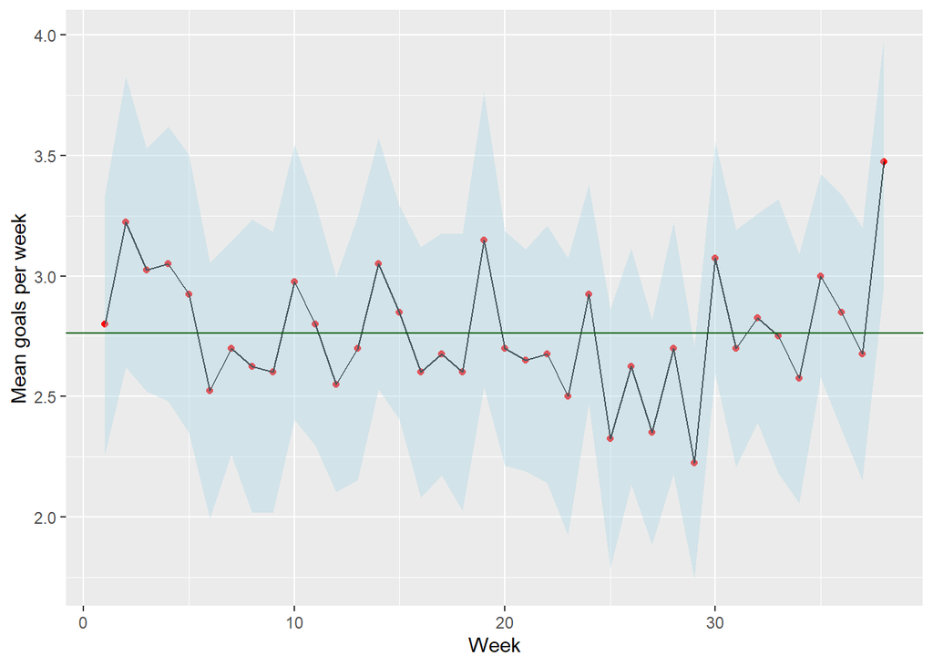

```r
#############################################
## Time series for number of goals
week_totalgoals <- data1  %>%
  select(Time, Week, Total_goals) %>%
  group_by(Week) %>%
  summarise(total_goals_week = mean(Total_goals)) %>%
  arrange(Week)

## Add in confidence intervals using normality (use t distribution)
confidence_intervals <- data1 %>%
  group_by(Week) %>%
  summarise(lower_ci = mean(Total_goals) - qt(0.975, n() - 1) * (sd(Total_goals) / sqrt(n())),
            upper_ci = mean(Total_goals) + qt(0.975, n() - 1) * (sd(Total_goals) / sqrt(n())))

## Merge the total_goals_week column into confidence_intervals
confidence_intervals <- confidence_intervals %>%
  left_join(week_totalgoals, by = "Week")

#############################################
## Ggplot for weekly mean goal count
ggplot(data = week_totalgoals, aes(y = total_goals_week, x = Week)) + geom_point(color = 'red') +
  geom_line() +
  geom_ribbon(data = confidence_intervals, aes(x = Week,
                                               ymin = lower_ci,
                                               ymax = upper_ci),
              fill = 'lightblue', alpha = 0.4) +
  labs(y = "Mean goals per week") +
  geom_abline(slope = 0, intercept=mean(week_totalgoals$total_goals_week),
              color = 'darkgreen')
```

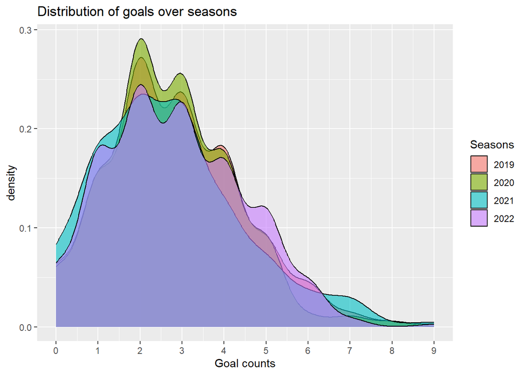

```r
#############################################
## Histogram for number of goals scored (distribution of goals) across seasons
data1 %>% select(Season_End_Year, Total_goals) %>%
  ggplot(aes(fill = as.factor(Season_End_Year), x = Total_goals)) +
  geom_density(position = 'identity', alpha = 0.6) +
    scale_x_continuous(breaks = seq(0, max(data1$Total_goals), by = 1))+
  labs(title = "Distribution of goals over seasons",
       x = 'Goal counts',
       fill = "Seasons")
```

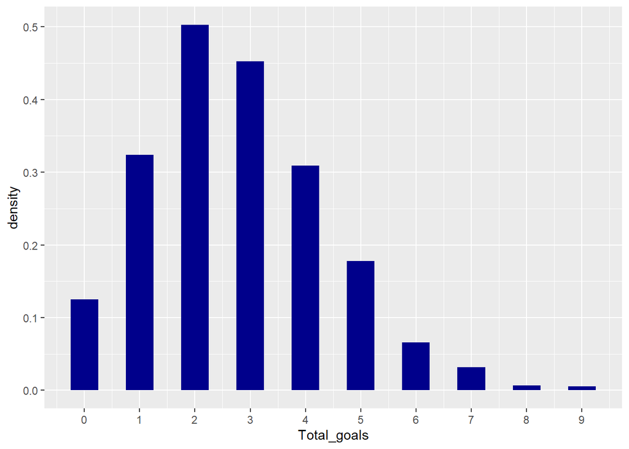

```r
#############################################
## Histogram for number of goals scored
data1 %>% select(Season_End_Year, Total_goals) %>%
  ggplot(aes(x = Total_goals)) +
  geom_histogram(aes(y = ..density..), binwidth = .5, fill = 'darkblue') +
  scale_x_continuous(breaks = seq(0, max(data1$Total_goals), by = 1)) +
  theme_gray()
```

```r
## Fit a poisson using MLE
total_goals <- data1 %>% dplyr::select(Total_goals)
poisson_fit <- MASS::fitdistr(as.numeric(unlist(total_goals)), 'poisson')

## This is the same as just finding the mean (MLE)
pois_rate <- mean(unlist(total_goals))
poisson_fit
```

```
##      lambda
##   2.76381579
##  (0.04264153)
```

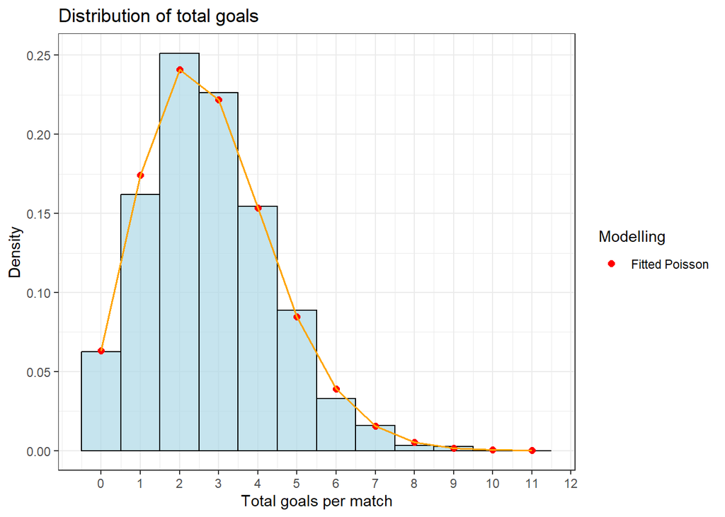

```r
######### Plot the histogram and the Poisson density on top

## First, use dpois to get the density across a range of x values (i.e. density for each number of goals, since discrete PMF)
x_values <- 0:11
fitted_poisson_density <- dpois(lambda = pois_rate, x = x_values)
# Save as a df for easier plotting on ggplot
fitted_pois_df <- data.frame(fitted_poisson_density, x_values)

## Plot both histogram and the fitted poisson
ggplot()+
  geom_histogram(data = data1, aes(x = Total_goals, y = ..density..),
                 position = 'identity',
                 binwidth = 1,
                 fill = 'lightblue',
                 color = 'black',
                 alpha = 0.7) +
  geom_point(data = fitted_pois_df, aes(y = fitted_poisson_density,
                                x = x_values,color = 'Fitted Poisson'),

            size = 2)+
  geom_line(data = fitted_pois_df, aes(y = fitted_poisson_density,
                                x = x_values),
            color = 'orange',
            size = .7) +
  theme_bw() +
  labs(title = 'Distribution of total goals',
       y = 'Density',
       x = 'Total goals per match') +
  scale_color_manual(values = 'red',
                     guide = guide_legend(title = 'Modelling')) +
  scale_x_continuous(breaks = 0:12)
```

The poisson fit for the distribution of total goals per match looks like a decent fit, with the mean being between 2 and 3.

Due to the ability of the Poisson model to capture the number of goals, we can extent this to the GLM framework and use a Poisson GLM to try to model the goals. For this I will try to replicate the Poisson GLM model done by [dashee87](https://dashee87.github.io/data%20science/football/r/predicting-football-results-with-statistical-modelling/)

Importantly, we want to reshape the data such that for every game, there will now be two rows: one for the home team and one for the away team, and now the new variable `home` will be a binary variable that is either 0 or 1 (therefore a doubling of the number of rows).

This allows us to properly model the number of goals scored as a function of the `home` indicator.

```r
## Step 1 -- reorganise the table such that we capture the goals as a single column, and add a home binary variable, same as Dashee87

## Save reshaper function as a function
reshape_data <- function(dataframe) {
  return(rbind(data.frame(goals=dataframe$HomeGoals,
             team=dataframe$Home, ## the team that scored the goals (home)
             opponent=dataframe$Away,
             home=1,
             xg = dataframe$Home_xG),
             data.frame(goals=dataframe$AwayGoals,
             team=dataframe$Away, ## the team that scores the goals (away)
             opponent=dataframe$Home,
             home=0,
             xg = dataframe$Away_xG)))
}

data1_reshaped <- reshape_data(data1)

## Step 2 -- direct the pipeline into the GLM
poisson_model <- data1_reshaped %>% ## pipe into GLM model
  glm(goals ~ ., family = poisson(link = log),
      data = .)

## Get the fitted GLM results
summary(poisson_model)
```

```
##
## Call:
## glm(formula = goals ~ ., family = poisson(link = log), data = .)
##
## Deviance Residuals:
##     Min       1Q   Median       3Q      Max
## -2.8296  -1.0878  -0.0607   0.4847   2.8373
##
## Coefficients:
##                          Estimate Std. Error z value Pr(>|z|)
## (Intercept)             -0.455349   0.105017  -4.336 1.45e-05 ***
## teamAston Villa         -0.073725   0.104504  -0.705 0.480517
## teamBournemouth         -0.124129   0.120755  -1.028 0.303977
## teamBrentford           -0.072871   0.158322  -0.460 0.645322
## teamBrighton            -0.271164   0.102882  -2.636 0.008397 **
## teamBurnley             -0.257539   0.103188  -2.496 0.012567 *
## teamCardiff City        -0.397657   0.183522  -2.167 0.030249 *
## teamChelsea             -0.014647   0.088841  -0.165 0.869046
## teamCrystal Palace      -0.123160   0.099934  -1.232 0.217797
## teamEverton             -0.112376   0.097384  -1.154 0.248521
## teamFulham              -0.461725   0.143643  -3.214 0.001307 **
## teamHuddersfield        -0.610333   0.223461  -2.731 0.006309 **
## teamLeeds United        -0.040554   0.117374  -0.346 0.729707
## teamLeicester City       0.006974   0.090352   0.077 0.938472
## teamLiverpool            0.044150   0.084975   0.520 0.603368
## teamManchester City      0.038622   0.083701   0.461 0.644496
## teamManchester Utd       0.011934   0.089185   0.134 0.893547
## teamNewcastle Utd       -0.129087   0.100450  -1.285 0.198762
## teamNorwich City        -0.576676   0.157278  -3.667 0.000246 ***
## teamSheffield Utd       -0.457504   0.145623  -3.142 0.001680 **
## teamSouthampton         -0.123764   0.097657  -1.267 0.205034
## teamTottenham            0.099599   0.088831   1.121 0.262195
## teamWatford             -0.264905   0.111224  -2.382 0.017232 *
## teamWest Brom           -0.245749   0.181306  -1.355 0.175277
## teamWest Ham            -0.022946   0.092823  -0.247 0.804756
## teamWolves              -0.180323   0.099969  -1.804 0.071265 .
## opponentAston Villa      0.097580   0.106833   0.913 0.361037
## opponentBournemouth      0.293482   0.113351   2.589 0.009621 **
## opponentBrentford        0.224237   0.152714   1.468 0.142010
## opponentBrighton         0.112717   0.101580   1.110 0.267156
```

[output cut: 18 more lines]

```
## opponentWest Brom        0.252635   0.136946   1.845 0.065069 .
## opponentWest Ham         0.087276   0.100309   0.870 0.384263
## opponentWolves           0.041464   0.104694   0.396 0.692072
## home                     0.032713   0.031380   1.042 0.297189
## xg                       0.485054   0.018410  26.348  < 2e-16 ***
## ---
## Signif. codes:  0 '***' 0.001 '**' 0.01 '*' 0.05 '.' 0.1 ' ' 1
##
## (Dispersion parameter for poisson family taken to be 1)
##
##     Null deviance: 3963.5  on 3039  degrees of freedom
## Residual deviance: 2695.6  on 2987  degrees of freedom
## AIC: 8188.5
##
## Number of Fisher Scoring iterations: 5
```

```r
## Home advantage estimate?
home_adv_coeff <-poisson_model$coefficients[names(poisson_model$coefficients) == 'home']

names(home_adv_coeff) <- NULL
```

Since this is a Poisson model, the linear effects are on the log(#goals), hence to get the effect on the true #goals we need to exponentiate the coefficient.

In this case, the multiplicative effect of being at home, on average and all else constant, is 103.3253792 % on the number of goals scored.

Since the variables are categorical, we need to remember that the coefficients represent the change in average outcome of a team *with respect to the base category*, which is Arsenal.

xG is clearly a strong predictor of the number of goals.

With more data, we could consider adding in interaction terms. For example, the home team effect of Liverpool may be much stronger than another club. In this case, using the same coefficient for the home effect across all clubs may be unfair.

```r
## With the current data from 2019 to 2022 seasons
## Interactions
poisson_model_2 <- data1_reshaped %>% ## pipe into GLM model
  glm(goals ~ home*team, family = poisson(link = log),
      data = .)

## Summary
summary(poisson_model_2)
```

```
##
## Call:
## glm(formula = goals ~ home * team, family = poisson(link = log),
##     data = .)
##
## Deviance Residuals:
##     Min       1Q   Median       3Q      Max
## -2.3786  -1.2566  -0.1088   0.6037   4.0451
##
## Coefficients:
##                           Estimate Std. Error z value Pr(>|z|)
## (Intercept)               0.351398   0.096225   3.652 0.000260 ***
## home                      0.237850   0.128680   1.848 0.064547 .
## teamAston Villa          -0.174941   0.154807  -1.130 0.258449
## teamBournemouth          -0.204794   0.178846  -1.145 0.252173
## teamBrentford            -0.037740   0.218451  -0.173 0.862837
## teamBrighton             -0.351398   0.149723  -2.347 0.018926 *
## teamBurnley              -0.364643   0.150308  -2.426 0.015267 *
## teamCardiff City         -0.730888   0.293564  -2.490 0.012785 *
## teamChelsea               0.177681   0.130427   1.362 0.173102
## teamCrystal Palace       -0.160343   0.141876  -1.130 0.258408
## teamEverton              -0.263291   0.145971  -1.804 0.071275 .
## teamFulham               -0.587787   0.206379  -2.848 0.004398 **
## teamHuddersfield         -0.810930   0.304285  -2.665 0.007698 **
## teamLeeds United          0.054067   0.163716   0.330 0.741212
## teamLeicester City        0.113659   0.132377   0.859 0.390560
## teamLiverpool             0.335149   0.126023   2.659 0.007827 **
## teamManchester City       0.417735   0.123923   3.371 0.000749 ***
## teamManchester Utd        0.088553   0.133168   0.665 0.506068
## teamNewcastle Utd        -0.378066   0.150906  -2.505 0.012235 *
## teamNorwich City         -1.098612   0.254564  -4.316 1.59e-05 ***
## teamSheffield Utd        -0.853490   0.229645  -3.717 0.000202 ***
## teamSouthampton          -0.216223   0.144061  -1.501 0.133377
## teamTottenham             0.121890   0.132121   0.923 0.356235
## teamWatford              -0.351398   0.163715  -2.146 0.031841 *
## teamWest Brom            -0.300105   0.243430  -1.233 0.217645
## teamWest Ham             -0.117783   0.140270  -0.840 0.401085
## teamWolves               -0.351398   0.149723  -2.347 0.018926 *
## home:teamAston Villa     -0.075331   0.209199  -0.360 0.718779
## home:teamBournemouth     -0.070796   0.241901  -0.293 0.769779
```

[output cut: 18 more lines]

```
## home:teamTottenham       -0.079026   0.178180  -0.444 0.657391
## home:teamWatford         -0.106514   0.222455  -0.479 0.632074
## home:teamWest Brom       -0.525532   0.364996  -1.440 0.149916
## home:teamWest Ham         0.041989   0.186679   0.225 0.822036
## home:teamWolves          -0.004235   0.200332  -0.021 0.983135
## ---
## Signif. codes:  0 '***' 0.001 '**' 0.01 '*' 0.05 '.' 0.1 ' ' 1
##
## (Dispersion parameter for poisson family taken to be 1)
##
##     Null deviance: 3963.5  on 3039  degrees of freedom
## Residual deviance: 3504.9  on 2988  degrees of freedom
## AIC: 8995.9
##
## Number of Fisher Scoring iterations: 5
```

```r
#################################################################
## Use more data from previous seasons
data2 <- worldfootballR::fb_match_results(country = "ENG", gender = "M", season_end_year = c(2010:2022))

head(data2)
```

```
##   Competition_Name Gender Country Season_End_Year Round Wk Day       Date Time
## 1   Premier League      M     ENG            2010    NA  1 Sat 2009-08-15 <NA>
## 2   Premier League      M     ENG            2010    NA  1 Sat 2009-08-15 <NA>
## 3   Premier League      M     ENG            2010    NA  1 Sat 2009-08-15 <NA>
## 4   Premier League      M     ENG            2010    NA  1 Sat 2009-08-15 <NA>
## 5   Premier League      M     ENG            2010    NA  1 Sat 2009-08-15 <NA>
## 6   Premier League      M     ENG            2010    NA  1 Sat 2009-08-15 <NA>
##         Home HomeGoals            Away AwayGoals Attendance Venue
## 1    Chelsea         2       Hull City         1         NA  <NA>
## 2 Stoke City         2         Burnley         0         NA  <NA>
## 3    Everton         1         Arsenal         6         NA  <NA>
## 4 Portsmouth         0          Fulham         1         NA  <NA>
## 5  Blackburn         0 Manchester City         2         NA  <NA>
## 6     Bolton         0      Sunderland         1         NA  <NA>
##           Referee Notes
```

[output cut: 20 more lines]

```r
nrow(data2) ## there are 19 games a season for 20 teams, hence 380 games a season in total
```

```
## [1] 4940
```

```r
## Since there are 13 seasons, then we have 13*380

## Reshape the data so that we can run it through the GLM
data2_reshaped <- reshape_data(data2)

poisson_model_3 <- data2_reshaped %>% ## pipe into GLM model
  glm(goals ~ home*team, family = poisson(link = log),
      data = .)

summary(poisson_model_3)
```

```
##
## Call:
## glm(formula = goals ~ home * team, family = poisson(link = log),
##     data = .)
##
## Deviance Residuals:
##     Min       1Q   Median       3Q      Max
## -2.2729  -1.2920  -0.1018   0.6150   4.2177
##
## Coefficients:
##                           Estimate Std. Error z value Pr(>|z|)
## (Intercept)               0.472026   0.050252   9.393  < 2e-16 ***
## home                      0.243144   0.067123   3.622 0.000292 ***
## teamAston Villa          -0.435846   0.087186  -4.999 5.76e-07 ***
## teamBirmingham City      -0.498694   0.171908  -2.901 0.003720 **
## teamBlackburn            -0.437540   0.139551  -3.135 0.001717 **
## teamBlackpool            -0.197589   0.206216  -0.958 0.337980
## teamBolton               -0.472026   0.141665  -3.332 0.000862 ***
## teamBournemouth          -0.371942   0.109768  -3.388 0.000703 ***
## teamBrentford            -0.158368   0.202452  -0.782 0.434066
## teamBrighton             -0.571555   0.118967  -4.804 1.55e-06 ***
## teamBurnley              -0.561432   0.098587  -5.695 1.24e-08 ***
## teamCardiff City         -0.890736   0.206211  -4.320 1.56e-05 ***
## teamChelsea               0.024939   0.070628   0.353 0.724011
## teamCrystal Palace       -0.340690   0.087484  -3.894 9.85e-05 ***
## teamEverton              -0.361013   0.078412  -4.604 4.14e-06 ***
## teamFulham               -0.652845   0.107397  -6.079 1.21e-09 ***
## teamHuddersfield         -0.931558   0.210194  -4.432 9.34e-06 ***
## teamHull City            -0.832467   0.146261  -5.692 1.26e-08 ***
## teamLeeds United         -0.066561   0.141665  -0.470 0.638466
## teamLeicester City       -0.102279   0.084087  -1.216 0.223856
## teamLiverpool             0.068319   0.069884   0.978 0.328266
## teamManchester City       0.181901   0.068048   2.673 0.007515 **
## teamManchester Utd       -0.002528   0.071112  -0.036 0.971636
## teamMiddlesbrough        -1.113880   0.320175  -3.479 0.000503 ***
## teamNewcastle Utd        -0.511055   0.086605  -5.901 3.61e-09 ***
## teamNorwich City         -0.801505   0.121325  -6.606 3.94e-11 ***
## teamPortsmouth           -1.113880   0.320189  -3.479 0.000504 ***
## teamQPR                  -0.507744   0.143899  -3.528 0.000418 ***
## teamReading              -0.420733   0.229183  -1.836 0.066389 .
```

[output cut: 44 more lines]

```
## home:teamWatford         -0.014511   0.144840  -0.100 0.920196
## home:teamWest Brom        0.022965   0.123596   0.186 0.852593
## home:teamWest Ham         0.030985   0.106186   0.292 0.770442
## home:teamWigan Athletic  -0.098313   0.169494  -0.580 0.561889
## home:teamWolves          -0.063351   0.135685  -0.467 0.640571
## ---
## Signif. codes:  0 '***' 0.001 '**' 0.01 '*' 0.05 '.' 0.1 ' ' 1
##
## (Dispersion parameter for poisson family taken to be 1)
##
##     Null deviance: 12854  on 9879  degrees of freedom
## Residual deviance: 11566  on 9802  degrees of freedom
## AIC: 29174
##
## Number of Fisher Scoring iterations: 5
```

Even with including more data (13 seasons), we fail to get statistical significance for the interaction term between home effect and the various clubs. This possibly is due to the random nature of football, with goals being something that is very hard to predict due to too many factors being at play.

## xG vs Actual goals?

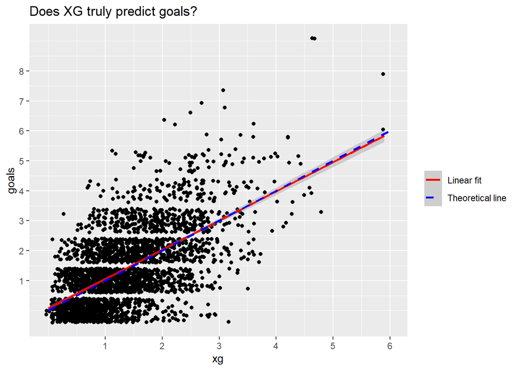

```r
data1_reshaped %>%
  select(goals, xg) %>%
  ggplot() +
  geom_jitter(aes(x = xg, y = goals)) + ## since the goals is discrete, many points will be overlapping, therefore good to use jitter
  geom_smooth(aes(x = xg, y = goals, color = 'Linear fit'), method = 'lm') +
  geom_line(data = data.frame(x = 0:6, y = 0:6, label = 'Theoretical line'),
            aes(x = x, y = y, color = label), linetype = 'dashed', size = 1 ) +
  scale_color_manual(values = c('red', 'blue', 'black'),
                     labels = c('Linear fit', 'Theoretical line'),
                     guide = guide_legend(override.aes = list(linetype = c('solid', 'dashed')))) +
  labs(color = '', ## Add a legend label for the color variable used to distinguish the lines
       title = 'Does XG truly predict goals?')+
  scale_x_continuous(breaks = 1:8) +
  scale_y_continuous(breaks = 1:8)
```

## Does Liverpool have statistically significant different results with different referees?

## What is the home ground advantage for Liverpool (or for all clubs)

```r
Liverpool_2018_2021 <- data2 %>% filter(Home == "Liverpool" | Away == "Liverpool")

## Create Win, Draw, Lost dummy(binary) columns for Liverpool
Liverpool_2018_2021$'Win' <- (Liverpool_2018_2021$Home == "Liverpool" & (Liverpool_2018_2021$HomeGoals > Liverpool_2018_2021$AwayGoals))|(Liverpool_2018_2021$Away == "Liverpool" &( Liverpool_2018_2021$HomeGoals < Liverpool_2018_2021$AwayGoals))

Liverpool_2018_2021$`Win` <- as.integer(Liverpool_2018_2021$`Win`)

Liverpool_2018_2021$'Draw' <- as.integer(Liverpool_2018_2021$HomeGoals == Liverpool_2018_2021$AwayGoals)

Liverpool_2018_2021$'Loss' <- as.integer((!Liverpool_2018_2021$Win) &(!Liverpool_2018_2021$Draw))

## Check
table(Liverpool_2018_2021$`Win`)
```

```
##
##   0   1
## 216 278
```

```r
table(rowSums(Liverpool_2018_2021[c("Win", "Draw", "Loss")])) ## Dummy variables all add to one (one hot vector)
```

```
##
##   1
## 494
```

```r
## Liverpool
Liverpool_2018_2021 <- Liverpool_2018_2021 %>% select(Season_End_Year, Home, HomeGoals, Away, AwayGoals, Referee)%>%
  mutate(Opponent = if_else(Home == "Liverpool", Away, Home),
         IsHomeTeam = if_else(Home == "Liverpool", 1, 0))
#  select(-Home, -Away) # Remove original Home and Away columns if desired

## Reshape it so that the focus of the dataset is on Liverpool
Liverpool_reshaped <- Liverpool_2018_2021 %>%
   mutate(LiverpoolWon = if_else((Home == "Liverpool" & HomeGoals > AwayGoals) | (Away == "Liverpool" & AwayGoals > HomeGoals), 1, 0))

#######################################################
## Predict Liverpool Win (Logistic model for Liverpool Win)

liverpool_win_logitistic_model <- glm(LiverpoolWon ~ as.factor(Season_End_Year) + as.factor(Referee) + Opponent + IsHomeTeam,
    data = Liverpool_reshaped,
    family = binomial(link = "logit"),
    contrasts = list(Season_End_Year = "contr.treatment", Referee = "contr.treatment", Opponent = "contr.treatment"))
summary(liverpool_win_logitistic_model)
```

```
##
## Call:
## glm(formula = LiverpoolWon ~ as.factor(Season_End_Year) + as.factor(Referee) +
##     Opponent + IsHomeTeam, family = binomial(link = "logit"),
##     data = Liverpool_reshaped, contrasts = list(Season_End_Year = "contr.treatment",
##         Referee = "contr.treatment", Opponent = "contr.treatment"))
##
## Deviance Residuals:
##     Min       1Q   Median       3Q      Max
## -2.0357  -0.8821   0.2627   0.8793   1.9891
##
## Coefficients:
##                                      Estimate Std. Error z value Pr(>|z|)
## (Intercept)                           0.28642    1.34695   0.213 0.831604
## as.factor(Season_End_Year)2011        0.07864    0.58553   0.134 0.893158
## as.factor(Season_End_Year)2012       -0.66611    0.60848  -1.095 0.273642
## as.factor(Season_End_Year)2013       -0.03227    0.60489  -0.053 0.957455
## as.factor(Season_End_Year)2014        1.30613    0.62723   2.082 0.037306 *
## as.factor(Season_End_Year)2015       -0.21266    0.63479  -0.335 0.737617
## as.factor(Season_End_Year)2016       -0.27330    0.64148  -0.426 0.670072
## as.factor(Season_End_Year)2017        0.49815    0.65086   0.765 0.444047
## as.factor(Season_End_Year)2018       -0.05507    0.65390  -0.084 0.932888
## as.factor(Season_End_Year)2019        1.35579    0.68423   1.981 0.047536 *
## as.factor(Season_End_Year)2020        1.97984    0.74142   2.670 0.007577 **
## as.factor(Season_End_Year)2021       -0.10759    0.65789  -0.164 0.870096
## as.factor(Season_End_Year)2022        1.12726    0.69309   1.626 0.103857
## as.factor(Referee)Andre Marriner     -1.35963    1.37153  -0.991 0.321531
## as.factor(Referee)Andy Madley        14.58150 3956.18063   0.004 0.997059
## as.factor(Referee)Anthony Taylor     -1.28414    1.39487  -0.921 0.357251
## as.factor(Referee)Chris Kavanagh     -0.09770    1.76581  -0.055 0.955877
## as.factor(Referee)Craig Pawson       -0.60863    1.44714  -0.421 0.674065
## as.factor(Referee)David Coote       -22.28074 3956.18067  -0.006 0.995506
## as.factor(Referee)Graham Scott       16.02694 1743.32180   0.009 0.992665
## as.factor(Referee)Howard Webb        -2.07089    1.44270  -1.435 0.151165
## as.factor(Referee)Jon Moss           -2.40604    1.73209  -1.389 0.164804
## as.factor(Referee)Jonathan Moss      -0.34277    1.50846  -0.227 0.820243
## as.factor(Referee)Kevin Friend       -1.21715    1.41964  -0.857 0.391243
## as.factor(Referee)Lee Mason          -1.50571    1.43111  -1.052 0.292738
## as.factor(Referee)Lee Probert         0.13716    1.54678   0.089 0.929340
## as.factor(Referee)Mark Clattenburg   -1.16793    1.46627  -0.797 0.425721
```

[output cut: 49 more lines]

```
## OpponentWest Brom                     0.05597    0.73160   0.077 0.939017
## OpponentWest Ham                      0.64175    0.67263   0.954 0.340043
## OpponentWigan Athletic                0.24463    0.92516   0.264 0.791454
## OpponentWolves                        2.03959    0.95940   2.126 0.033511 *
## IsHomeTeam                            0.86558    0.22281   3.885 0.000102 ***
## ---
## Signif. codes:  0 '***' 0.001 '**' 0.01 '*' 0.05 '.' 0.1 ' ' 1
##
## (Dispersion parameter for binomial family taken to be 1)
##
##     Null deviance: 677.03  on 493  degrees of freedom
## Residual deviance: 511.76  on 413  degrees of freedom
## AIC: 673.76
##
## Number of Fisher Scoring iterations: 16
```

```r
## Check reference categories
Liverpool_reshaped <- Liverpool_reshaped %>% mutate(Referee = as.factor(Referee),
                              Opponent = as.factor(Opponent))

levels(Liverpool_reshaped$Referee) ## Reference referee: Alan Wiley
```

```
##  [1] "Alan Wiley"       "Andre Marriner"   "Andy Madley"      "Anthony Taylor"
##  [5] "Chris Kavanagh"   "Craig Pawson"     "David Coote"      "Graham Scott"
##  [9] "Howard Webb"      "Jon Moss"         "Jonathan Moss"    "Kevin Friend"
## [13] "Lee Mason"        "Lee Probert"      "Mark Clattenburg" "Mark Halsey"
## [17] "Mark Jones"       "Martin Atkinson"  "Michael Oliver"   "Mike Dean"
## [21] "Mike Jones"       "Neil Swarbrick"   "Niel Swarbrick"   "Paul Tierney"
## [25] "Peter Walton"     "Phil Dowd"        "Philip Dowd"      "Robert Madley"
## [29] "Roger East"       "Stephen Bennett"  "Stuart Attwell"
```

```r
levels(Liverpool_reshaped$Opponent) ## Reference opponent: Arsenal
```

```
##  [1] "Arsenal"         "Aston Villa"     "Birmingham City" "Blackburn"
##  [5] "Blackpool"       "Bolton"          "Bournemouth"     "Brentford"
##  [9] "Brighton"        "Burnley"         "Cardiff City"    "Chelsea"
## [13] "Crystal Palace"  "Everton"         "Fulham"          "Huddersfield"
## [17] "Hull City"       "Leeds United"    "Leicester City"  "Manchester City"
## [21] "Manchester Utd"  "Middlesbrough"   "Newcastle Utd"   "Norwich City"
## [25] "Portsmouth"      "QPR"             "Reading"         "Sheffield Utd"
## [29] "Southampton"     "Stoke City"      "Sunderland"      "Swansea City"
## [33] "Tottenham"       "Watford"         "West Brom"       "West Ham"
## [37] "Wigan Athletic"  "Wolves"
```

Take note that there are reference categories for the factorial variables, e.g. referee and opposition.

## Try some Bayesian modelling? (unsuccessful)

Main Source: Leonardo Egidi (https://cran.r-project.org/web/packages/footBayes/vignettes/footBayes_a_rapid_guide.html#modeling-football-outcomes), 2022

It is known that the number of goals scored by both teams are generally correlated – let us look at the past data to see if we can find some sort of correlation between the home and away sides. My off-the-bat theory was that there should be a positive correlation, since the more one side scores, the harder the other side would try to score to catch up and hopefully turn the tide around and win the game.

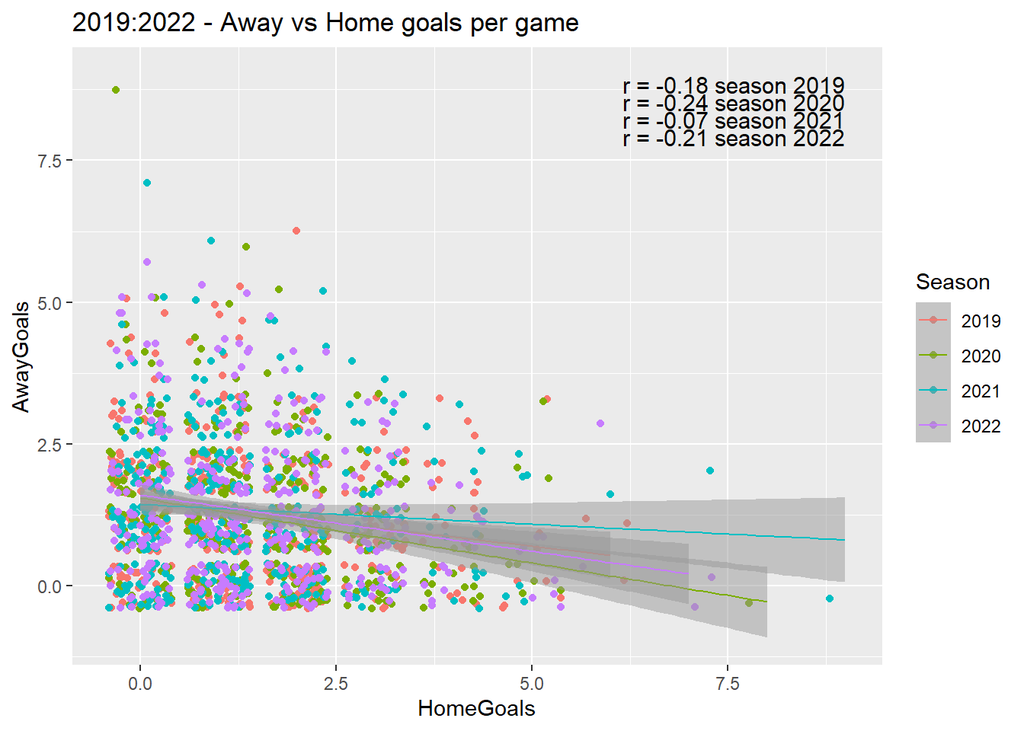

```r
## correlation coefficients
correlation_by_season <- data1 %>% select(Home, Away, HomeGoals, AwayGoals, Season_End_Year) %>%
  group_by(Season_End_Year) %>%
  summarise(correlation = cor(HomeGoals, AwayGoals))

## Method 1: my own -------------------------------------------------------------

## ggplot, and add in the numeric coefficients for year on year
# data1 %>% select(Home, Away, HomeGoals, AwayGoals, Season_End_Year) %>%
#   ggplot(aes(x = HomeGoals, y = AwayGoals, color = as.factor(Season_End_Year))) +
#   geom_jitter() +
#   labs(title = "2019:2022 - Away vs Home goals per game",
#        color = "Season") +
#   geom_smooth(aes(x = HomeGoals, y = AwayGoals),
#               method = 'lm', se = T, alpha = 0.5, linetype = 1, linewidth = .5) +
#   ## add geom text to add in the correlation data
#   geom_text(data = correlation_by_season,
#             aes(x = max(data1$HomeGoals), y = max(data1$AwayGoals), label = paste0("r = ", round(correlation, 2))),
#             hjust = 1, vjust = 1, color = "black", size = 4,
#             position = position_dodge(width = 1))
#
## Method 2: chatgpt v1 -------------------------------------------------------------


# Plot with correlation coefficients
p <- data1 %>%
  select(Home, Away, HomeGoals, AwayGoals, Season_End_Year) %>%
  ggplot(aes(x = HomeGoals, y = AwayGoals, color = as.factor(Season_End_Year))) +
  geom_jitter() +
  labs(title = "2019:2022 - Away vs Home goals per game", color = "Season") +
  geom_smooth(aes(x = HomeGoals, y = AwayGoals),
              method = 'lm', se = T, alpha = 0.5, linetype = 1, linewidth = .5)

# Add correlation coefficients as separate text layers
## Iteratively add each text containing each season's correlation coefficients
for (i in 1:nrow(correlation_by_season)) {
  p <- p +
    geom_text(data = correlation_by_season[i, ],
              aes(x = max(data1$HomeGoals), y = max(data1$AwayGoals),
                  label = paste0("r = ", round(correlation, 2), " season ", Season_End_Year)),
              color = "black", size = 4,
              hjust = 1, vjust = 1*i) ## keep adjusting the position each time - so that the corr coeffs do not overlap
}

# Display the plot
p
```

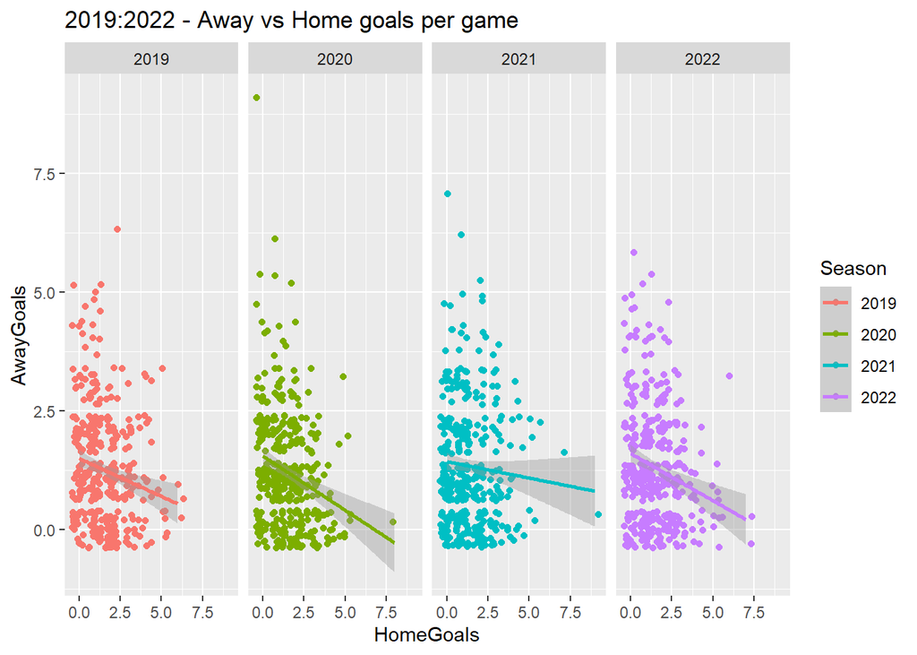

```r
## =======================================================
## Plot version 2 : To see each season more clearly

data1 %>%
  select(Home, Away, HomeGoals, AwayGoals, Season_End_Year) %>%
  ggplot(aes(x = HomeGoals, y = AwayGoals, color = as.factor(Season_End_Year))) +
  geom_jitter()+
  geom_smooth(method = 'lm')+
  facet_grid(~Season_End_Year) +
  labs(title = "2019:2022 - Away vs Home goals per game", color = "Season")
```

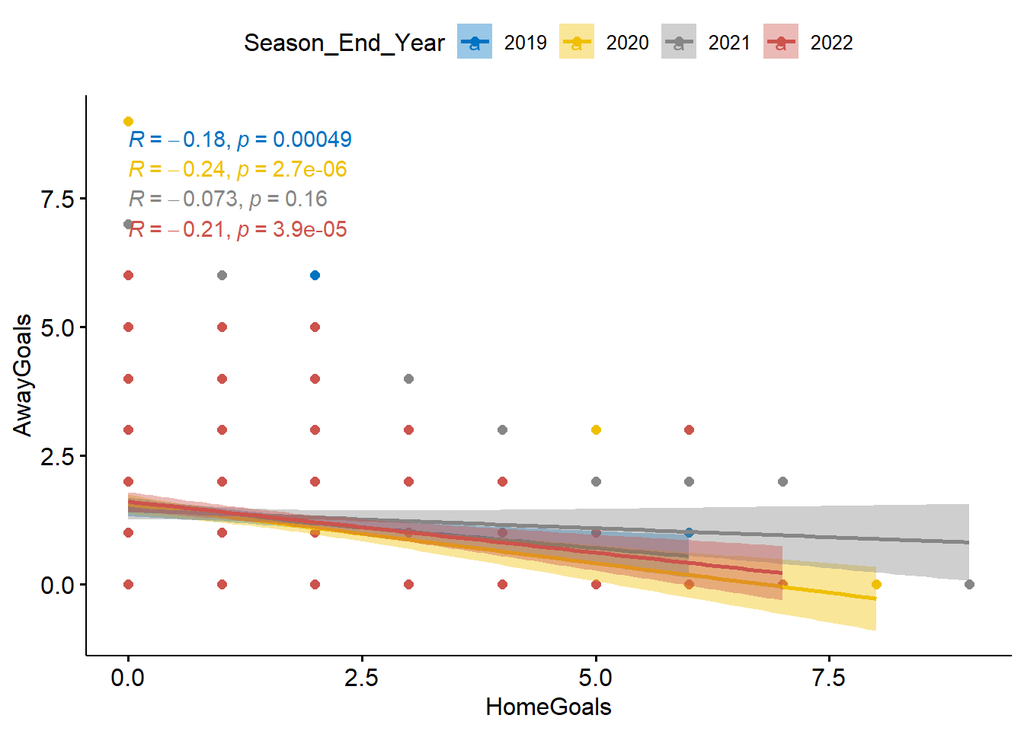

```r
## Load ggpubr plotting functionality
#install.packages('ggpubr')
library(ggpubr)

## use ggscatter from the ggpubr library
data1$Season_End_Year <- as.factor(data1$Season_End_Year)
data1 %>%
  select(Home, Away, HomeGoals, AwayGoals, Season_End_Year) %>%
  ggscatter(x = "HomeGoals", y = "AwayGoals",col = "Season_End_Year", palette = 'jco',
            add = 'reg.line', conf.int = T) +
  stat_cor(aes(color = (Season_End_Year))) #+
```

```r
  #facet_wrap(~ Season_End_Year, ncol = 1)
```

ggscatter has nice functionalities that allows us to not only plot out each regression curve per season but also displays the correlation coefficient and also the assosicated p value.

Strangely enough, it looks like it is negatively correlated - could this be the result of some Simpson’s paradox? After plotting out and differentiating the points across seasons, we can see from both plots that the correlations are indeed negative and are statistically significantly so (perhaps apart from 2021, where the correlation coefficient itself is close to 0 and the p value is pretty high - suggesting insufficient evidence to reject the null that the correlation coefficient isn’t 0).

As argued in Leonardo’s article, there should be some psychological effect on seeing your team being down by a few goals and the natural motivation to try to at least equalise. Despite our correlation coefficient most likely being negative in this case, we will nevertheless proceed the same way and use a **bivariate Poisson** distribution to capture the dependence parameter between the goals scored and the goals conceded per game.

For a bivariate Poisson distribution, unlike that of a univariate Poisson, we now need 2 more parameters, in total 3:

As Leonardo argues, we can estimate these parameters via MLE, and get Wald type confidence intervals for the estimates for static models, however when the parameter space grows, MLE becomes more computationally expensive and less reliable than Bayesian inference methods.

While MLE doesn’t consider a prior and finds an estimate purely from the data itself (e.g. MLE for most parameters are the sample average, e.g. when estimating the probability parameter of a bernoulli distribution like a coin flip), and gives a single value to the parameter (fixed estimate) via the Frequentist method. On the other hand, Bayesian methods allow the parameter to be randomly distributed in the first place (distributed over an appropriate support, for example between 0 and 1 for a probability parameter).

In Bayesian inference, we try to get the posterior distribution of the parameter of interest $\pi(\theta | \mathbf{Y})$, we need to first decide on a prior $\pi(\theta)$ and then factor in the data using the likelihood function $P(\mathbf{Y})$

Unfortunately, in most cases, we cannot get closed form solutions for the posterior, and in these cases we need to use **Monte Carlo Markov Methods** where we draw dependent samples from a chain whose equilibrium distribution is the posterior distribution of interest.

We usually run the sampler for a long while before we start using the sampled data for estimation purposes - this is called the burn in period, where we are waiting for the sampler to converge to the true posterior distribution of interest.

```r
mle_fit_italy2000 <- mle_foot(italy_2000,
                       model = "biv_pois",
                       interval = 'wald')
                      #chains = 4,
                       #iter = n_iterations)



mle_fit_italy2000$att
```

```
##                2.5%   mle 97.5%
## Udinese Calcio 0.09  0.09  0.09
## AS Roma          NA  0.41    NA
## AC Perugia       NA  0.07    NA
## Reggina Calcio   NA -0.36    NA
## SSC Napoli       NA -0.31    NA
## AC Milan         NA  0.23    NA
## Atalanta         NA -0.22    NA
## AS Bari          NA -0.42    NA
## Parma AC         NA  0.14    NA
## Inter            NA  0.05    NA
## Vicenza Calcio   NA -0.22    NA
## Hellas Verona    NA -0.15    NA
## US Lecce         NA -0.15    NA
## Juventus         NA  0.29    NA
## ACF Fiorentina   NA  0.16    NA
## Brescia Calcio   NA -0.03    NA
## Bologna FC       NA  0.07    NA
## Lazio Roma       NA  0.36    NA
```

```r
mle_fit_italy2000$def
```

```
##                2.5%   mle 97.5%
## Udinese Calcio 0.29  0.29  0.29
## AS Roma          NA -0.36    NA
## AC Perugia       NA  0.16    NA
## Reggina Calcio   NA  0.09    NA
## SSC Napoli       NA  0.10    NA
## AC Milan         NA  0.03    NA
## Atalanta         NA -0.34    NA
## AS Bari          NA  0.42    NA
## Parma AC         NA -0.37    NA
## Inter            NA  0.05    NA
## Vicenza Calcio   NA  0.12    NA
## Hellas Verona    NA  0.26    NA
## US Lecce         NA  0.17    NA
## Juventus         NA -0.59    NA
## ACF Fiorentina   NA  0.15    NA
## Brescia Calcio   NA -0.08    NA
## Bologna FC       NA  0.15    NA
## Lazio Roma       NA -0.26    NA
```

```r
mle_fit_italy2000$home
```

```
##      2.5% mle 97.5%
## [1,]   NA 0.3    NA
```

```r
mle_fit_italy2000$corr
```

```
##      2.5%  mle 97.5%
## [1,]   NA 0.14    NA
```

The lack of confidence intervals could be due to the sample size. Let us apply this same MLE modelling to our EPL data from 2019 to 2022.

```r
## Check and match the same columns
colnames(italy_2000)
```

```
## [1] "Season"  "home"    "visitor" "hgoal"   "vgoal"
```

```r
## Prepare our data for the bivariate fitting
epl_2019_2022 <- data1 %>% select(Season_End_Year, Home, Away, HomeGoals, AwayGoals)

## Fit the bivariate Poisson and get MLE
mle_fit_epl <- mle_foot(epl_2019_2022,
                       model = "biv_pois",
                       interval = 'wald')


## Check results
## Attacking stats
sort((mle_fit_epl$att)[,2])
```

```
##    Huddersfield    Norwich City   Sheffield Utd          Fulham    Cardiff City
##           -1.02           -0.68           -0.48           -0.47           -0.43
##       West Brom        Brighton         Burnley         Watford   Newcastle Utd
##           -0.36           -0.16           -0.15           -0.10           -0.05
##          Wolves  Crystal Palace       Brentford         Everton     Bournemouth
##           -0.05           -0.03            0.00            0.05            0.06
##     Southampton     Aston Villa    Leeds United        West Ham         Arsenal
##            0.06            0.11            0.16            0.23            0.33
##  Leicester City  Manchester Utd       Tottenham         Chelsea       Liverpool
##            0.35            0.40            0.41            0.41            0.64
## Manchester City
##            0.77
```

```r
## Defensive stats
sort((mle_fit_epl$def)[,2])
```

```
## Manchester City       Liverpool         Chelsea       Tottenham          Wolves
##           -0.62           -0.57           -0.28           -0.22           -0.19
##         Arsenal  Manchester Utd   Sheffield Utd        Brighton  Leicester City
##           -0.14           -0.11           -0.09           -0.07           -0.07
##       Brentford  Crystal Palace         Everton        West Ham     Aston Villa
##           -0.05            0.00            0.00            0.01            0.03
##         Burnley   Newcastle Utd          Fulham     Southampton    Leeds United
##            0.05            0.07            0.20            0.20            0.20
##         Watford    Cardiff City     Bournemouth       West Brom    Huddersfield
##            0.22            0.22            0.24            0.30            0.31
##    Norwich City
##            0.37
```

```r
## Correlation
mle_fit_epl$corr
```

```
##      2.5%  mle 97.5%
## [1,]   NA 0.06    NA
```

```r
mle_fit_epl$home
```

```
##      2.5%  mle 97.5%
## [1,]   NA 0.22    NA
```

As expected, Liverpool and Mancity have the best stats for both attack and defence.

Comparing the coefficient between the Italian league during 2000, and our EPL during 2019 to 2022, we have 0.14 vs 0.06